# Multi-species Occupancy Models

Ecological Forecasting Initiative

Christopher Rota

4/4/2022

# Acknowledgments

- Ken Kellner
- Roland Kays
- Arielle Parsons
- Many coauthors

[figure not shown]

# Multi-species Occupancy Models (MSOM)

- Model occupancy probability of multiple species simultaneously
- Infer patterns of dependence between species
- All while accounting for imperfect detection

[figure not shown]

# What can we Learn from MSOMs?

- Test for dependence between species
- Do species interactions vary along a gradient?
- Marginal occupancy probability
- Conditional occupancy
- Is occurrence more strongly driven by environmental gradients or interspecific interactions?

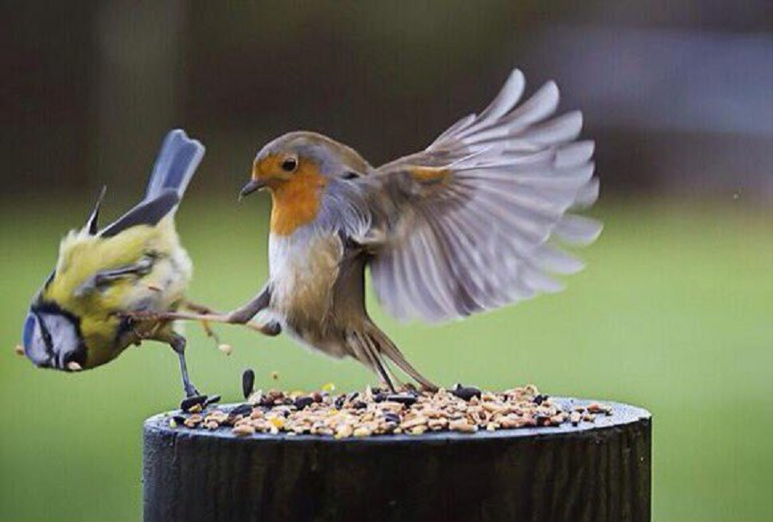

# Different Flavors of MSOMs

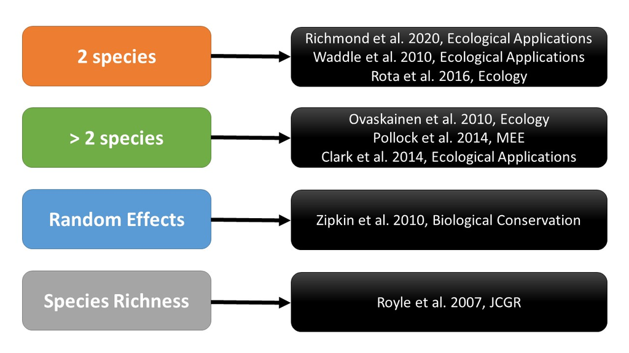

Today’s webinar is focused on techniques described by [Rota et al. 2016](https://doi.org/10.1111/2041-210X.12587).

# Technical Details: Natural Parameters

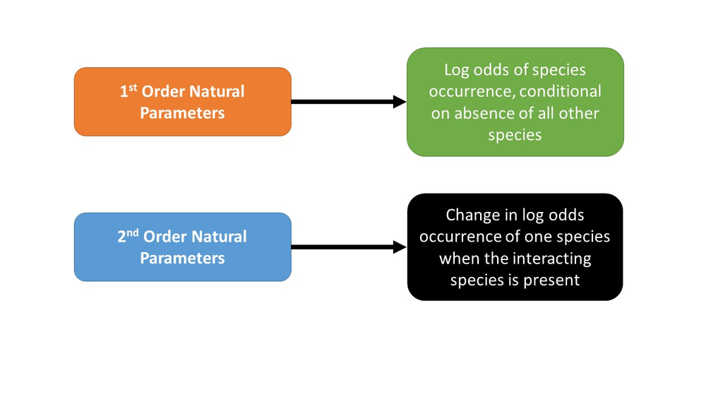

# Technical Details: Natural Parameters

Let $S$ represent the number of species

- $S$ $1^{st}$ order natural parameters
- ${S \choose 2}$ $2^{nd}$ order natural parameters
- Up to $2^S-1$ natural parameters of maximum order $S$

**Example**: let $S = 3$:

- ${3 \choose 1} = 3$ $1^{st}$ order natural parameters
- ${3 \choose 2} = 3$ $2^{nd}$ order natural parameters
- ${3 \choose 3} = 1$ $3^{rd}$ order natural parameters
- $2 ^ 3 - 1 = 7$ total natural parameters

*I only incorporate $1^{st}$ and $2^{nd}$ order natural parameters for this talk.*

# Technical Details: Marginal Occupancy

- Common method for interpreting occupancy probability
- Averages over presence / absence of all other species
- Complex function of natural parameters
  - i.e., *not* directly obtained from model output
- Functions for implementation in `unmarked`
- Mathematical details in [Rota et al. 2016](https://doi.org/10.1111/2041-210X.12587)

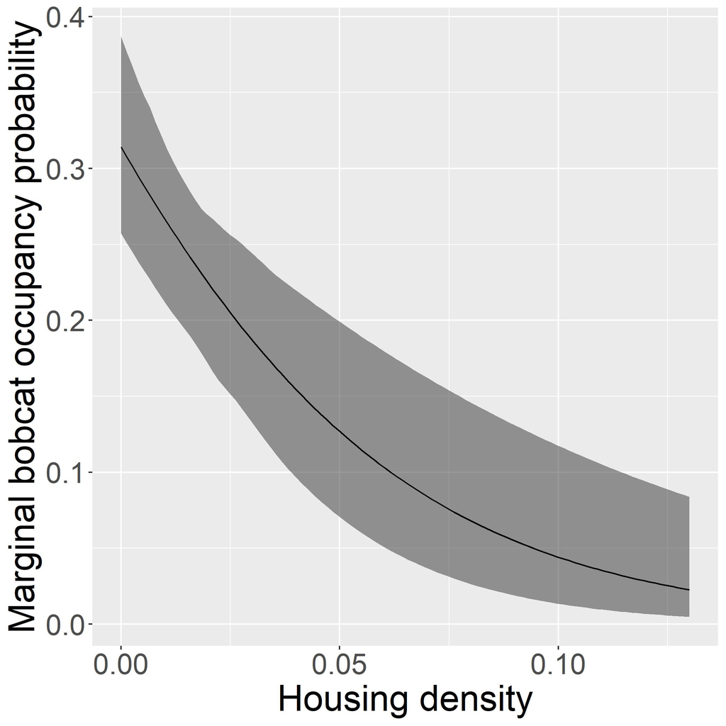

# Technical Details: Conditional Occupancy

- Method for evaluating occupancy of one species when other species are present / absent
- In specific cases, can be directly obtained from model output
  - Log odds occupancy of each species, conditional on absence of all others
- In other cases, a complex function of natural parameters
- Functions for implementation in `unmarked`
- Mathematical details in [Rota et al. 2016](https://doi.org/10.1111/2041-210X.12587)

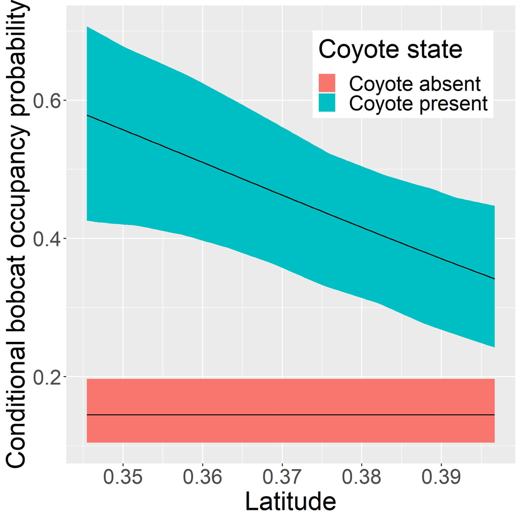

# Basic Sampling Procedure

Same general procedure for single-species occupancy models:

- survey for *S* species at *N* sites selected from a population of interest
- at each site *i*, conduct $J_i$ replicate surveys
- for each species *s*, during replicate survey *j* at site *i*, record detection ($y_{sij} = 1$) or non-detection ($y_{sij} = 0$)
- record detection-level covariates during each replicate detection / non-detection survey
- record site-level covariates at each site *i*

# Impelementation in `unmarked`

- Incorporated into `unmarked` by Dr. Ken Kellner
- Similar syntax to other models implemented in `unmarked`

Let’s first review our example data set and then format for analysis in `unmarked`.

# Data

- Data from 1437 camera traps placed across 6 states in the mid-Atlantic region, USA
- Distilled to Coyote, Bobcat, and Red Fox
- Cameras deployed 3 weeks
- 1-week replicate sampling period
  - Species recorded as detected if observed at least once during each 1-week sampling period
- Site-level occupancy covariates, observation-level detection covariates
- Details in [Kays et al. 2016](https://doi.org/10.1111/1365-2664.12700)

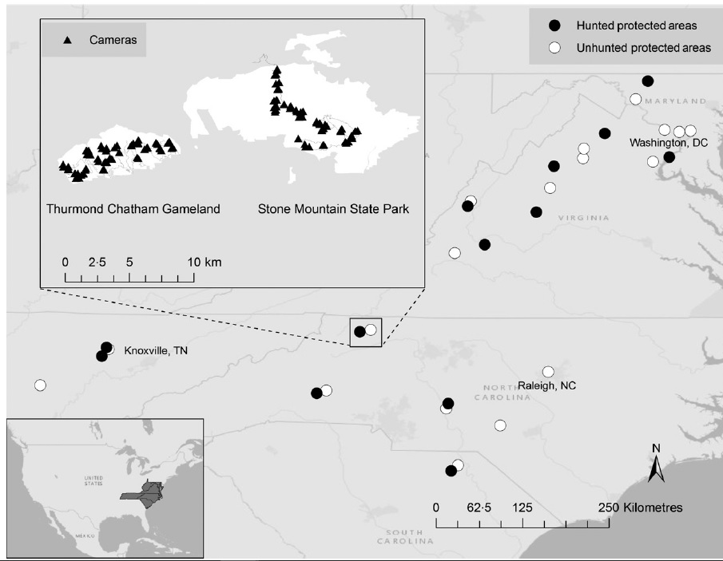

# Data

Let’s read in and examine our data.

Load detection / non-detection data:

```r
bob <- read.csv('data/Bobcat_3wk.csv', header = F)
coy <- read.csv('data/Coyote_3wk.csv', header = F)
fox <- read.csv('data/RedFox_3wk.csv', header = F)
```

Inspect red fox detection / non-detection data:

```r
head(fox)
```

```
##   V1 V2 V3
## 1  0  0  0
## 2  0  0  0
## 3  0  0  1
## 4  0  0  0
## 5  0  0  0
## 6  1  1  1
```

# Data

Load site-level covariate data:

```r
occ_covs <- read.csv('data/psi_cov3wk.csv')
```

Inspect site-level covariates:

```r
head(occ_covs)
```

```
##   Dist_5km HDens_5km  Latitude  Longitude People_site Trail
## 1     0.04  9.345258 0.3899441 -0.7723958       0.857     1
## 2     0.03  9.499197 0.3899250 -0.7723920       0.002     0
## 3     0.03  9.647173 0.3899111 -0.7723954       0.387     1
## 4     0.03  9.598066 0.3899166 -0.7723972       0.003     0
## 5     0.03  9.607825 0.3899179 -0.7724004       0.000     0
## 6     0.03  9.748791 0.3899058 -0.7724046       0.443     1
```

# Data

Site-level covariate descriptions:

- `Dist_5km`: Proportion disturbance within 5km
- `HDens_5km`: Housing density within 5km
- `Latitude` / `Longitude`: Latitude and longitude
- `People_site`: Total people recorded / 1000
- `Trail`: binary indicator of whether camera was on trail (1) or not (0)

# Data

Load detection covariates:

```r
det_covs <- read.csv('data/detection data.csv')
```

Inspect detection covariates:

```r
head(det_covs)
```

```
##        Temp1      Temp2      Temp3
## 1  0.8685909 0.03711437 -0.1788084
## 2  0.8497885 0.92470119  1.3023852
## 3  0.8556828 0.92044332  0.1927059
## 4  0.8555556 0.92032423  0.1975017
## 5  0.8554921 0.92025869  0.1974762
## 6 -0.2674792 0.38300270  0.1003521
```

# Loading the `unmarked` package

Load the `unmarked` package

```r
# devtools::install_github("rbchan/unmarked") this will take a while
library(unmarked)
```

- The CRAN download will be sufficient for everything except penalized likelihood (at the end)
- Downloading the latest version from GitHub will allow you to fit penalized likelihood models (available on CRAN soon)

# Formatting Data

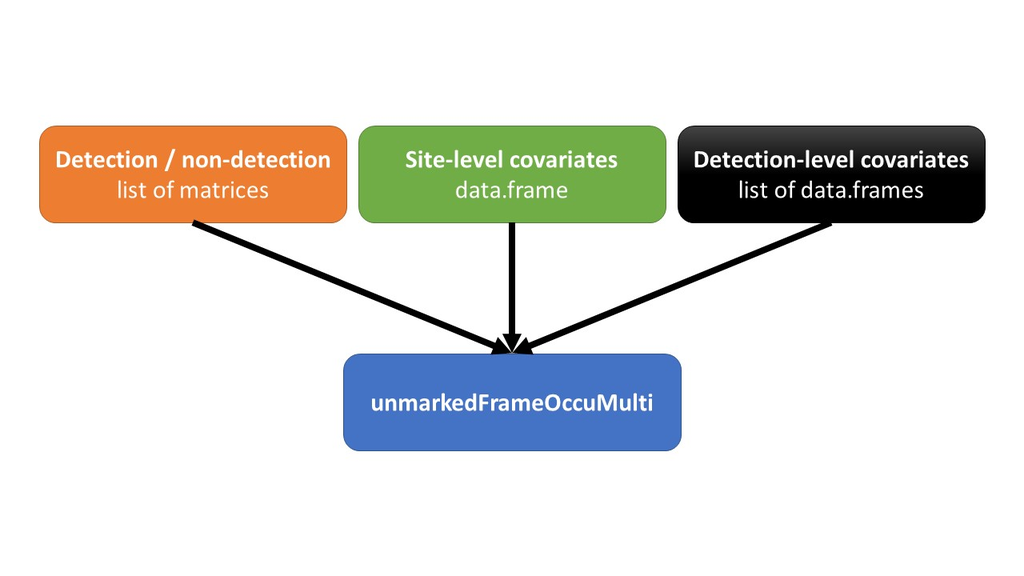

# Formatting

Place detection / non-detection data into a named list.

- *each element of the list must be a matrix*

```r
y_list <- list(bobcat = as.matrix(bob),
               coyote = as.matrix(coy),
               redfox = as.matrix(fox))
```

Place detection covariates into a named list.

- *each element of the list must be of the same dimension as each detection / non-detection matrix*

```r
det_list <- list(temp = det_covs)
```

Combine data into an `unmarkedFrameOccuMulti` object:

```r
msom_data <- unmarkedFrameOccuMulti(y = y_list,
                                    siteCovs = occ_covs,
                                    obsCovs = det_list)
```

# Intercept-only model, assuming independence

Syntax similar to other models in `unmarked`

- 1 detection formula for each species
- 1 occupancy formula for each *natural parameter* included in model
- formulas specified as character vector
- order of formulas follows detection / non-detection list

### Fit a model

For now, we assume independence among species. We do this by only allowing $1^{st}$ order natural parameters (`maxOrder = 1`).

```r
fit_1 <- occuMulti(detformulas = c('~1', '~1', '~1'),
                   stateformulas = c('~1', '~1', '~1'),
                   maxOrder = 1,
                   data = msom_data)
```

# Intercept-only model, assuming independence

This is equivalent to fitting 3 single-species occupancy models

```r
summary(fit_1)
```

```
##
## Call:
## occuMulti(detformulas = c("~1", "~1", "~1"), stateformulas = c("~1",
##     "~1", "~1"), data = msom_data, maxOrder = 1)
##
## Occupancy (logit-scale):
##                      Estimate     SE      z  P(>|z|)
## [bobcat] (Intercept)   -1.171 0.1328  -8.82 1.13e-18
## [coyote] (Intercept)   -0.629 0.0744  -8.46 2.79e-17
## [redfox] (Intercept)   -1.846 0.0944 -19.56 3.58e-85
##
## Detection (logit-scale):
##                      Estimate     SE     z  P(>|z|)
## [bobcat] (Intercept)   -1.104 0.1396 -7.91 2.59e-15
## [coyote] (Intercept)   -0.333 0.0764 -4.36 1.30e-05
## [redfox] (Intercept)   -0.252 0.1182 -2.13 3.29e-02
##
## AIC: 6710.658
## Number of sites: 1437
## optim convergence code: 0
## optim iterations: 50
## Bootstrap iterations: 0
```

# Intercept-only model, assuming dependence

- Set `maxOrder = 2` to estimate up to $2^{nd}$ order natural parameters
- Permits dependence between species
- Fixes all natural parameters > `maxOrder` at 0

```r
fit_2 <- occuMulti(detformulas = c('~1', '~1', '~1'),
                   stateformulas = c('~1', '~1', '~1',
                                     '~1', '~1', '~1'),
                   maxOrder = 2,
                   data = msom_data)
```

# Intercept-only model, assuming dependence

Inspecting the $2^{nd}$ order natural parameters from the fitted model permits us to evaluate interspecific dependence.

```r
summary(fit_2)
```

```
##
## Call:
## occuMulti(detformulas = c("~1", "~1", "~1"), stateformulas = c("~1",
##     "~1", "~1", "~1", "~1", "~1"), data = msom_data, maxOrder = 2)
##
## Occupancy (logit-scale):
##                             Estimate    SE      z  P(>|z|)
## [bobcat] (Intercept)           -1.76 0.179  -9.81 1.03e-22
## [coyote] (Intercept)           -1.30 0.137  -9.54 1.37e-21
## [redfox] (Intercept)           -2.20 0.152 -14.44 2.81e-47
## [bobcat:coyote] (Intercept)     1.72 0.262   6.56 5.48e-11
## [bobcat:redfox] (Intercept)    -1.38 0.377  -3.66 2.57e-04
## [coyote:redfox] (Intercept)     1.41 0.248   5.69 1.31e-08
##
## Detection (logit-scale):
##                      Estimate     SE     z  P(>|z|)
## [bobcat] (Intercept)   -1.106 0.1398 -7.91 2.59e-15
## [coyote] (Intercept)   -0.331 0.0761 -4.35 1.38e-05
## [redfox] (Intercept)   -0.253 0.1183 -2.13 3.28e-02
##
## AIC: 6626.111
## Number of sites: 1437
## optim convergence code: 0
## optim iterations: 48
## Bootstrap iterations: 0
```

- bobcat and coyote occur together more frequently than expected by chance ($p < 0.01$)
- bobcat and red fox occur together less frequently than expected by chance ($p < 0.01$)
- coyote and red fox occur together more frequently than expected by chance ($p < 0.01$)
- AIC strongly favors the model incorporating dependence

# Incorporating covariates

- *Any* parameter can be modeled as a function of covariates
- Covariate models for each parameter can be unique
- Names of detection covariates correspond to names provided in named list
- Names of occupancy covariates correspond to names in data.frame

The model below is driven less by biology and more by an interest in demonstrating that each parameter can be modeled uniquely.

```r
fit_3 <- occuMulti(detformulas = c('~temp', '~1', '~1'),
                   stateformulas = c('~Dist_5km', '~HDens_5km', '~People_site',
                                     '~Latitude', '~1', '~1'),
                   maxOrder = 2,
                   data = msom_data)
```

# Incorporating covariates

Interpreting output

```r
summary(fit_3)
```

```
##
## Call:
## occuMulti(detformulas = c("~temp", "~1", "~1"), stateformulas = c("~Dist_5km",
##     "~HDens_5km", "~People_site", "~Latitude", "~1", "~1"), data = msom_data,
##     maxOrder = 2)
##
## Occupancy (logit-scale):
##                              Estimate      SE      z  P(>|z|)
## [bobcat] (Intercept)         -1.35970 0.19131  -7.11 1.18e-12
## [bobcat] Dist_5km           -22.95531 5.90074  -3.89 1.00e-04
## [coyote] (Intercept)         -1.48520 0.17195  -8.64 5.74e-18
## [coyote] HDens_5km            0.00424 0.00232   1.83 6.74e-02
## [redfox] (Intercept)         -2.45677 0.16226 -15.14 8.72e-52
## [redfox] People_site          5.92772 1.27022   4.67 3.06e-06
## [bobcat:coyote] (Intercept)   8.89548 2.78788   3.19 1.42e-03
## [bobcat:coyote] Latitude    -18.97578 7.30167  -2.60 9.35e-03
## [bobcat:redfox] (Intercept)  -1.55839 0.42126  -3.70 2.16e-04
## [coyote:redfox] (Intercept)   1.55320 0.26507   5.86 4.64e-09
##
## Detection (logit-scale):
##                      Estimate     SE     z  P(>|z|)
## [bobcat] (Intercept)   -1.248 0.1439 -8.67 4.16e-18
## [bobcat] temp          -0.306 0.0848 -3.60 3.12e-04
## [coyote] (Intercept)   -0.322 0.0756 -4.26 2.05e-05
## [redfox] (Intercept)   -0.494 0.1295 -3.81 1.36e-04
##
## AIC: 6544.769
## Number of sites: 1437
## optim convergence code: 0
## optim iterations: 133
## Bootstrap iterations: 0
```

### Sample interpretations:

- For every 1-unit increase disturbance within 5km, the log odds of bobcat occurrence, *when coyote and red fox are absent*, declines by 22.96
- When latitude = 0, bobcats are more likely to occur at a site when coyotes are present (and vice versa, $p < 0.01$)
- For every 1 unit increase in Latitude, the log odds bobcats will occur at a site decreases by 18.98 if coyotes are also present, relative to equivalent sites where coyotes are absent
  - i.e., as we move north, bobcats are coyotes are less likely to occupy the same site
- For every 1-unit increase in temperature, the log odds of bobcat detection decreases by 0.31

# Conditional occupancy probability

Calculation of conditional and marginal occupancy probabilities is done with the `predict` function.

- Create a data.frame for predictions
  - The procedure is equivalent to creating data frames for all other applications of `predict`
- Include complete range of observed latitude; hold all other variables at their mean

```r
nd_cond <- data.frame(
  Dist_5km = rep(mean(occ_covs$Dist_5km), 100),
  HDens_5km = rep(mean(occ_covs$HDens_5km), 100),
  People_site = rep(mean(occ_covs$People_site), 100),
  Latitude = seq(min(occ_covs$Latitude), max(occ_covs$Latitude),
                 length.out = 100)
)
```

# Conditional occupancy probability

### Predicting bobcat occurrence when coyotes are present

- `species` indicates which species we assume when predicting occupancy
- `cond` indicates which species we are assuming is present or absent

```r
bob_coy_1 <- predict(fit_3, type = 'state', species = 'bobcat',
                     cond = 'coyote', newdata = nd_cond)
```

```
## Bootstrapping confidence intervals with 100 samples
```

### Predicting bobcat occurrence when coyotes are absent

- putting a `-` in front of coyote tells `predict` you wish to assume coyotes are absent

```r
bob_coy_0 <- predict(fit_3, type = 'state', species = 'bobcat',
                     cond = '-coyote', newdata = nd_cond)
```

```
## Bootstrapping confidence intervals with 100 samples
```

# Conditional occupancy probability

Formatting data for plotting in `ggplot`. I skip details, though this procedure is standard for plotting with `ggplot`.

```r
gg_df_cond <- data.frame(
  latitude = rep(nd_cond$Latitude, 2),
  occupancy = c(bob_coy_1$Predicted,
                bob_coy_0$Predicted),
  low = c(bob_coy_1$lower,
          bob_coy_0$lower),
  high = c(bob_coy_1$upper,
           bob_coy_0$upper),
  conditional = rep(c('Coyote present', 'Coyote absent'),
                    each = 100)
)
```

Creating a line plot, with ribbons representing limits of 95% confidence intervals. This is standard `ggplot2` code.

```r
library(ggplot2)

cond_fig <- ggplot(gg_df_cond, aes(x = latitude, y = occupancy,
                                   group = conditional)) +
  geom_ribbon(aes(ymin = low, ymax = high, fill = conditional)) +
  geom_line() +
  ylab('Conditional bobcat\noccupancy probability') +
  xlab('Latitude') +
  labs(fill = 'Coyote state') +
  theme(text = element_text(size = 25),
        legend.position = c(0.75, 0.85))
```

# Conditional occupancy probability

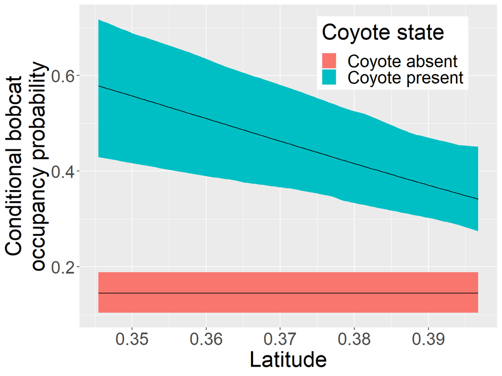

```r
cond_fig
```

Notice that when coyotes are present, there is a negative correlation with occupancy and latitude.

However, notice there is no relationship when coyotes are absent. This is consistent with our model for the bobcat $1^{st}$ order natural parameter, which is conditional on absence of coyote (and all other species).